# Customer Churnv2.- Updated

## Business Problem

Churn is one of the largest problems faced by most businesses. It costs between 5 times and 25 times as much to find a new customer than to retain an existing one. Therefore,anticipating when a customer churn is an important business objective. For the purposes of this report,

1. Telco dataset from IBM was utilised (Telecom Churn Dataset -https://www.ibm.com/communities/analytics/watson-analytics-blog/guide-to-sample-datasets/)
2. Report Objective: Build a model to predict whether a customer will churn

```python
import pandas as pd
import matplotlib.pyplot as plt
import seaborn as sns
from sklearn.preprocessing import LabelEncoder
import numpy as np
from sklearn.svm import SVC
import plotly.graph_objs as go
import plotly.offline as py
py.init_notebook_mode(connected=True)

%matplotlib inline
```

## Data Overview

```python
#Data Collection
df = pd.read_csv (r'C:\Users\User\Documents\Data science\Telco-Customer-Churn.csv')
# df = pd.read_csv('Telco-Customer-Churn.csv')
df.head()
```

|  | customerID | gender | SeniorCitizen | Partner | Dependents | tenure | PhoneService | MultipleLines | InternetService | OnlineSecurity | ... | DeviceProtection | TechSupport | StreamingTV | StreamingMovies | Contract | PaperlessBilling | PaymentMethod | MonthlyCharges | TotalCharges | Churn |
| --- | --- | --- | --- | --- | --- | --- | --- | --- | --- | --- | --- | --- | --- | --- | --- | --- | --- | --- | --- | --- | --- |
| 0 | 7590-VHVEG | Female | 0 | Yes | No | 1 | No | No phone service | DSL | No | ... | No | No | No | No | Month-to-month | Yes | Electronic check | 29.85 | 29.85 | No |
| 1 | 5575-GNVDE | Male | 0 | No | No | 34 | Yes | No | DSL | Yes | ... | Yes | No | No | No | One year | No | Mailed check | 56.95 | 1889.5 | No |
| 2 | 3668-QPYBK | Male | 0 | No | No | 2 | Yes | No | DSL | Yes | ... | No | No | No | No | Month-to-month | Yes | Mailed check | 53.85 | 108.15 | Yes |
| 3 | 7795-CFOCW | Male | 0 | No | No | 45 | No | No phone service | DSL | Yes | ... | Yes | Yes | No | No | One year | No | Bank transfer (automatic) | 42.30 | 1840.75 | No |
| 4 | 9237-HQITU | Female | 0 | No | No | 2 | Yes | No | Fiber optic | No | ... | No | No | No | No | Month-to-month | Yes | Electronic check | 70.70 | 151.65 | Yes |

5 rows × 21 columns

```python
#Data Overview
print("Rows:",df.shape[0])
print ("Columns:",df.shape[1])
print ("\nFeatures:\n",df.columns.tolist())
print ("\nMissingvalues:",df.isnull().sum().values.sum())
print ("\nUnique values:\n",df.nunique())
print (df['Churn'].value_counts())
```

```
Rows: 7043
Columns: 21

Features:
 ['customerID', 'gender', 'SeniorCitizen', 'Partner', 'Dependents', 'tenure', 'PhoneService', 'MultipleLines', 'InternetService', 'OnlineSecurity', 'OnlineBackup', 'DeviceProtection', 'TechSupport', 'StreamingTV', 'StreamingMovies', 'Contract', 'PaperlessBilling', 'PaymentMethod', 'MonthlyCharges', …

Missingvalues: 0

Unique values:
 customerID          7043
gender                 2
SeniorCitizen          2
Partner                2
Dependents             2
tenure                73
PhoneService           2
MultipleLines          3
InternetService        3
OnlineSecurity         3
OnlineBackup           3
DeviceProtection       3
TechSupport            3
StreamingTV            3
StreamingMovies        3
Contract               3
PaperlessBilling       2
PaymentMethod          4
MonthlyCharges      1585
TotalCharges        6531
Churn                  2
dtype: int64
No     5174
Yes    1869
Name: Churn, dtype: int64
```

```python
df.info()
```

```
<class 'pandas.core.frame.DataFrame'>
RangeIndex: 7043 entries, 0 to 7042
Data columns (total 21 columns):
customerID          7043 non-null object
gender              7043 non-null object
SeniorCitizen       7043 non-null int64
Partner             7043 non-null object
Dependents          7043 non-null object
tenure              7043 non-null int64
PhoneService        7043 non-null object
MultipleLines       7043 non-null object
InternetService     7043 non-null object
OnlineSecurity      7043 non-null object
OnlineBackup        7043 non-null object
DeviceProtection    7043 non-null object
TechSupport         7043 non-null object
StreamingTV         7043 non-null object
StreamingMovies     7043 non-null object
Contract            7043 non-null object
PaperlessBilling    7043 non-null object
PaymentMethod       7043 non-null object
MonthlyCharges      7043 non-null float64
TotalCharges        7043 non-null object
Churn               7043 non-null object
dtypes: float64(1), int64(2), object(18)
memory usage: 1.1+ MB
```

```python
df.TotalCharges = pd.to_numeric(df.TotalCharges, errors="coerce")
```

## Overview:

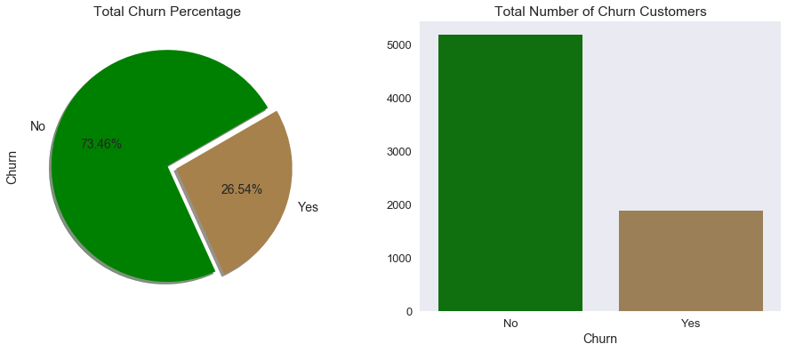

```python
plt.style.use(['seaborn-dark','seaborn-talk'])

fig, ax = plt.subplots(1,2,figsize=(16,6))

df['Churn'].value_counts().plot.pie(explode=[0,0.08], ax=ax[0], autopct='%1.2f%%', shadow=True,
                                    fontsize=14, startangle=30, colors=["#008000", "#a6814c"])
ax[0].set_title('Total Churn Percentage')

sns.countplot('Churn', data=df, ax=ax[1], palette=["#008000", "#a6814c"])
ax[1].set_title('Total Number of Churn Customers')
ax[1].set_ylabel(' ')

plt.show()
```

The data shows that 26.54% of the company's customers have decided to terminate the telco's service and left.

## Exploratory Data Analysis

```python
Id_col     = ['customerID']
target_col = ["Churn"]
cat_cols   = df.nunique()[df.nunique() < 6].keys().tolist()
cat_cols   = [x for x in cat_cols if x not in target_col]
num_cols   = [x for x in df.columns if x not in cat_cols + target_col + Id_col]

#Separating churn and non churn customers
churn     = df[df["Churn"] == "Yes"]
not_churn = df[df["Churn"] == "No"]
```

```python
def plot_pie(column) :

    trace1 = go.Pie(values  = churn[column].value_counts().values.tolist(),
                    labels  = churn[column].value_counts().keys().tolist(),
                    hoverinfo = "label+percent+name",
                    domain  = dict(x = [0,.48]),
                    name    = "Churn Customers",
                    marker  = dict(line = dict(width = 2,
                                               color = "rgb(33, 75, 99)")
                                  ),
                    hole    = .6
                   )
    trace2 = go.Pie(values  = not_churn[column].value_counts().values.tolist(),
                    labels  = not_churn[column].value_counts().keys().tolist(),
                    hoverinfo = "label+percent+name",
                    marker  = dict(line = dict(width = 2,
                                               color = "rgb(33, 75, 99)")
                                  ),
                    domain  = dict(x = [.52,1]),
                    hole    = .6,
                    name    = "Non Churn Customers"
                   )


    layout = go.Layout(dict(title = column + " distribution in customer attrition ",
                            plot_bgcolor  = "rgb(243,243,243)",
                            paper_bgcolor = "rgb(243,243,243)",
                            annotations = [dict(text = "churn customers",
                                                font = dict(size = 13),
                                                showarrow = False,
                                                x = .15, y = .5),
                                           dict(text = "Non Churn Customers",
                                                font = dict(size = 13),
                                                showarrow = False,
                                                x = .88,y = .5
                                               )
                                          ]
                           )
                      )
    data = [trace1,trace2]
    fig  = go.Figure(data = data,layout = layout)
    py.iplot(fig)
#function  for histogram for customer attrition types
def histogram(column) :
    trace1 = go.Histogram(x  = churn[column],
                          histnorm= "percent",
                          name = "Churn Customers",
                          marker = dict(line = dict(width = .5,
                                                    color = "black"
                                                    )
                                        ),
                         opacity = .9
                         )

    trace2 = go.Histogram(x  = not_churn[column],
                          histnorm = "percent",
                          name = "Non Churn customers",
                          marker = dict(line = dict(width = .5,
                                              color = "black"
                                             )
                                 ),
                          opacity = .9
                         )

    data = [trace1,trace2]
    layout = go.Layout(dict(title =column + " distribution in customer attrition ",
                            plot_bgcolor  = "rgb(243,243,243)",
                            paper_bgcolor = "rgb(243,243,243)",
                            xaxis = dict(gridcolor = 'rgb(255, 255, 255)',
                                             title = column,
                                             zerolinewidth=1,
                                             ticklen=5,
                                             gridwidth=2
                                            ),
                            yaxis = dict(gridcolor = 'rgb(255, 255, 255)',
                                             title = "percent",
                                             zerolinewidth=1,
                                             ticklen=5,
                                             gridwidth=2
                                            ),
                           )
                      )
    fig  = go.Figure(data=data,layout=layout)

    py.iplot(fig)

#function  for scatter plot matrix  for numerical columns in data
def scatter_matrix(df)  :

    df  = df.sort_values(by = "Churn" ,ascending = True)
    classes = df["Churn"].unique().tolist()
    classes

    class_code  = {classes[k] : k for k in range(2)}
    class_code

    color_vals = [class_code[cl] for cl in df["Churn"]]
    color_vals

    pl_colorscale = "Viridis"

    pl_colorscale

    text = [df.loc[k,"Churn"] for k in range(len(df))]
    text

    trace = go.Splom(dimensions = [dict(label  = "tenure",
                                       values = df["tenure"]),
                                  dict(label  = 'MonthlyCharges',
                                       values = df['MonthlyCharges']),
                                  dict(label  = 'TotalCharges',
                                       values = df['TotalCharges'])],
                     text = text,
                     marker = dict(color = color_vals,
                                   colorscale = pl_colorscale,
                                   size = 3,
                                   showscale = False,
                                   line = dict(width = .1,
                                               color='rgb(230,230,230)'
                                              )
                                  )
                    )
    axis = dict(showline  = True,
                zeroline  = False,
                gridcolor = "#fff",
                ticklen   = 4
               )

    layout = go.Layout(dict(title  =
                            "Scatter plot matrix for Numerical columns for customer attrition",
                            autosize = False,
                            height = 800,
                            width  = 800,
                            dragmode = "select",
                            hovermode = "closest",
                            plot_bgcolor  = 'rgba(240,240,240, 0.95)',
                            xaxis1 = dict(axis),
                            yaxis1 = dict(axis),
                            xaxis2 = dict(axis),
                            yaxis2 = dict(axis),
                            xaxis3 = dict(axis),
                            yaxis3 = dict(axis),
                           )
                      )
    data   = [trace]
    fig = go.Figure(data = data,layout = layout )
    py.iplot(fig)

#all categorical columns plot pie
for i in cat_cols :
    plot_pie(i)

#for all categorical columns plot pie
for i in cat_cols:
    plot_pie(i)

#for all categorical columns plot histogram
for i in num_cols :
    histogram(i)

#scatter plot matrix
scatter_matrix(df)
```

[interactive chart not shown]

#### Preliminary Finding

###### Churned Customer Profile

For better understanding we wanted to compare these important variables from costumers who churned and costumers who did not churned. Customer that churned are those who

1. Are majority pre-paid customers, as 88.6% of customer holds month-to-month renewal contracts
2. Have opted for paperless Billing (74.9%)
3. uses electronic checks (57.3%) and mailed checks (16.5%) as payment mode, which suggest that these customers tend to have cash-flow problem.
4. owns multiple lines
5. preferred fiber optic internet services,streaming TV (43.6%) and streaming movie (43.8%) services

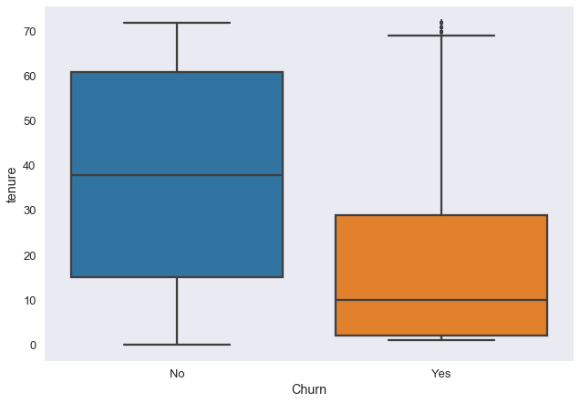

```python
# 1.1. Tenure vs Churn Relationship Analysis
import seaborn as sns
sns.boxplot (x='Churn',
            y='tenure',
            data=df)
sns.set_palette("cubehelix",3)
plt.show()
```

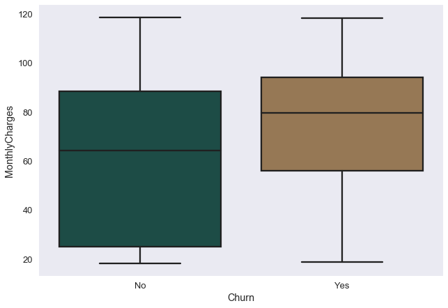

```python
# 1.2. Monthly Charges vs Churn Relationship Analysis
sns.boxplot (x='Churn',
            y='MonthlyCharges',
            data=df)
sns.set_palette("cubehelix",3)
plt.show()
```

Boxplot finding also indicates that there is a positive correlation between Monthly Charges and customer churn .

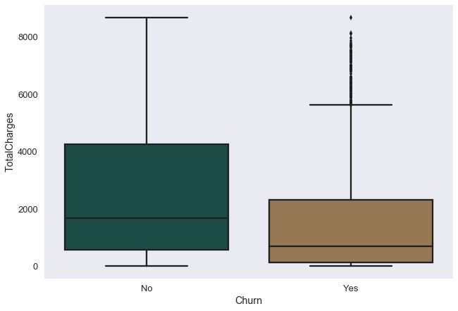

```python
# 1.3. Total Charges vs Churn Relationship Analysis
sns.boxplot(x='Churn',
            y='TotalCharges',
            data=df)
sns.set_palette("cubehelix",3)
plt.show()
```

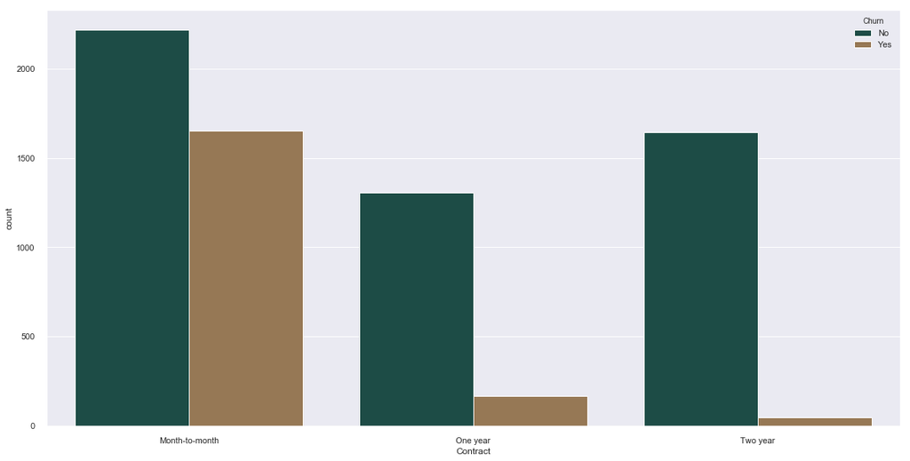

```python
# 1.3. Contract vs Churn Relationship Analysis
sns.set(style="darkgrid")
sns.set_palette("cubehelix",3)
fig, ax = plt.subplots(figsize=(20,10))
ax = sns.countplot(x="Contract", hue="Churn", data=df)
```

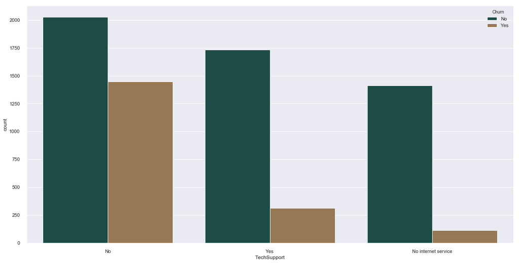

```python
# 1.4. TechSupport vs Churn Relationship Analysis
sns.set(style="darkgrid")
sns.set_palette("cubehelix",3)
fig, ax = plt.subplots(figsize=(20,10))
ax = sns.countplot(x="TechSupport", hue="Churn", data=df)
```

```python
#Preprocessing for Churn Modeling
df['gender'].replace(['Male','Female'],[0,1],inplace=True)
df['Partner'].replace(['Yes','No'],[1,0],inplace=True)
df['Dependents'].replace(['Yes','No'],[1,0],inplace=True)
df['PhoneService'].replace(['Yes','No'],[1,0],inplace=True)
df['MultipleLines'].replace(['No phone service','No', 'Yes'],[0,0,1],inplace=True)
df['InternetService'].replace(['No','DSL','Fiber optic'],[0,1,2],inplace=True)
df['OnlineSecurity'].replace(['No','Yes','No internet service'],[0,1,0],inplace=True)
df['OnlineBackup'].replace(['No','Yes','No internet service'],[0,1,0],inplace=True)
df['DeviceProtection'].replace(['No','Yes','No internet service'],[0,1,0],inplace=True)
df['TechSupport'].replace(['No','Yes','No internet service'],[0,1,0],inplace=True)
df['StreamingTV'].replace(['No','Yes','No internet service'],[0,1,0],inplace=True)
df['StreamingMovies'].replace(['No','Yes','No internet service'],[0,1,0],inplace=True)
df['Contract'].replace(['Month-to-month', 'One year', 'Two year'],[0,1,2],inplace=True)
df['PaperlessBilling'].replace(['Yes','No'],[1,0],inplace=True)
df['PaymentMethod'].replace(['Electronic check', 'Mailed check', 'Bank transfer (automatic)','Credit card (automatic)'],[0,1,2,3],inplace=True)
df['Churn'].replace(['Yes','No'],[1,0],inplace=True)

df.pop('customerID')
df.info()
```

```
<class 'pandas.core.frame.DataFrame'>
RangeIndex: 7043 entries, 0 to 7042
Data columns (total 20 columns):
gender              7043 non-null int64
SeniorCitizen       7043 non-null int64
Partner             7043 non-null int64
Dependents          7043 non-null int64
tenure              7043 non-null int64
PhoneService        7043 non-null int64
MultipleLines       7043 non-null int64
InternetService     7043 non-null int64
OnlineSecurity      7043 non-null int64
OnlineBackup        7043 non-null int64
DeviceProtection    7043 non-null int64
TechSupport         7043 non-null int64
StreamingTV         7043 non-null int64
StreamingMovies     7043 non-null int64
Contract            7043 non-null int64
PaperlessBilling    7043 non-null int64
PaymentMethod       7043 non-null int64
MonthlyCharges      7043 non-null float64
TotalCharges        7032 non-null float64
Churn               7043 non-null int64
dtypes: float64(2), int64(18)
memory usage: 1.1 MB
```

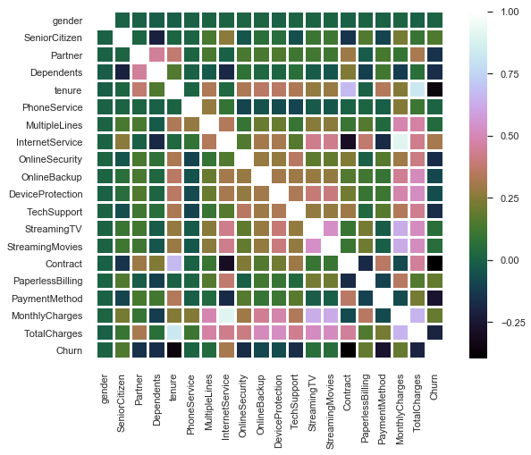

```python
#Future Scaling
sns.set(font_scale=1)
plot = sns.heatmap(df.corr(), cmap='cubehelix', linewidth=2, square = True)
```

To decide which features of the data to include in the predictive churn model, we’ll examine the correlation between churn and each customer feature. To avoid unstable estimates of coeffiecients and making it difficult to interprete in our models, we will drop the ‘TotalCharges’ variable, as it is highly correlated to both ‘Tenure’ and ‘MonthlyCharges’.

```python
df.pop('TotalCharges')
```

[output not shown]

[output cut: 47 more lines]

```python
#Future Scaling
categorical_features = [
"gender",
"SeniorCitizen",
"Partner",
"Dependents",
"PhoneService"
"MultipleLines",
"InternetService",
"OnlineSecurity",
"OnlineBackup",
"DeviceProtection",
"TechSupport",
"StreamingTV",
"StreamingMovies",
"Contract",
"PaperlessBilling",
"PaymentMethod",
]
numerical_features = ["tenure", "MonthlyCharges",]
target = "Churn"
```

```python
df[numerical_features].describe()
```

|  | tenure | MonthlyCharges |
| --- | --- | --- |
| count | 7043.000000 | 7043.000000 |
| mean | 32.371149 | 64.761692 |
| std | 24.559481 | 30.090047 |
| min | 0.000000 | 18.250000 |
| 25% | 9.000000 | 35.500000 |
| 50% | 29.000000 | 70.350000 |
| 75% | 55.000000 | 89.850000 |
| max | 72.000000 | 118.750000 |

```python
#Feature Engeering
### Examine correlations
df.corr()
```

|  | gender | SeniorCitizen | Partner | Dependents | tenure | PhoneService | MultipleLines | InternetService | OnlineSecurity | OnlineBackup | DeviceProtection | TechSupport | StreamingTV | StreamingMovies | Contract | PaperlessBilling | PaymentMethod | MonthlyCharges | Churn |
| --- | --- | --- | --- | --- | --- | --- | --- | --- | --- | --- | --- | --- | --- | --- | --- | --- | --- | --- | --- |
| gender | 1.000000 | 0.001874 | 0.001808 | -0.010517 | -0.005106 | 0.006488 | 0.008414 | 0.010380 | 0.017021 | 0.013773 | 0.002105 | 0.009212 | 0.008393 | 0.010487 | -0.000126 | 0.011754 | 0.005209 | 0.014569 | 0.008612 |
| SeniorCitizen | 0.001874 | 1.000000 | 0.016479 | -0.211185 | 0.016567 | 0.008576 | 0.142948 | 0.259390 | -0.038653 | 0.066572 | 0.059428 | -0.060625 | 0.105378 | 0.120176 | -0.142554 | 0.156530 | -0.093704 | 0.220173 | 0.150889 |
| Partner | 0.001808 | 0.016479 | 1.000000 | 0.452676 | 0.379697 | 0.017706 | 0.142057 | -0.000132 | 0.143106 | 0.141498 | 0.153786 | 0.119999 | 0.124666 | 0.117412 | 0.294806 | -0.014877 | 0.133115 | 0.096848 | -0.150448 |
| Dependents | -0.010517 | -0.211185 | 0.452676 | 1.000000 | 0.159712 | -0.001762 | -0.024526 | -0.179631 | 0.080972 | 0.023671 | 0.013963 | 0.063268 | -0.016558 | -0.039741 | 0.243187 | -0.111377 | 0.123844 | -0.113890 | -0.164221 |
| tenure | -0.005106 | 0.016567 | 0.379697 | 0.159712 | 1.000000 | 0.008448 | 0.331941 | 0.033230 | 0.327203 | 0.360277 | 0.360653 | 0.324221 | 0.279756 | 0.286111 | 0.671607 | 0.006152 | 0.340305 | 0.247900 | -0.352229 |
| PhoneService | 0.006488 | 0.008576 | 0.017706 | -0.001762 | 0.008448 | 1.000000 | 0.279690 | 0.093720 | -0.092893 | -0.052312 | -0.071227 | -0.096340 | -0.022574 | -0.032959 | 0.002247 | 0.016505 | -0.004070 | 0.247398 | 0.011942 |
| MultipleLines | 0.008414 | 0.142948 | 0.142057 | -0.024526 | 0.331941 | 0.279690 | 1.000000 | 0.344684 | 0.098108 | 0.202237 | 0.201137 | 0.100571 | 0.257152 | 0.258751 | 0.107114 | 0.163530 | 0.035851 | 0.490434 | 0.040102 |
| InternetService | 0.010380 | 0.259390 | -0.000132 | -0.179631 | 0.033230 | 0.093720 | 0.344684 | 1.000000 | 0.156799 | 0.307420 | 0.313603 | 0.164833 | 0.429707 | 0.427264 | -0.290189 | 0.378108 | -0.178137 | 0.905491 | 0.316846 |
| OnlineSecurity | 0.017021 | -0.038653 | 0.143106 | 0.080972 | 0.327203 | -0.092893 | 0.098108 | 0.156799 | 1.000000 | 0.283832 | 0.275438 | 0.354931 | 0.176207 | 0.187398 | 0.245530 | -0.003636 | 0.163367 | 0.296594 | -0.171226 |
| OnlineBackup | 0.013773 | 0.066572 | 0.141498 | 0.023671 | 0.360277 | -0.052312 | 0.202237 | 0.307420 | 0.283832 | 1.000000 | 0.303546 | 0.294233 | 0.282106 | 0.274501 | 0.155085 | 0.126735 | 0.096550 | 0.441780 | -0.082255 |
| DeviceProtection | 0.002105 | 0.059428 | 0.153786 | 0.013963 | 0.360653 | -0.071227 | 0.201137 | 0.313603 | 0.275438 | 0.303546 | 1.000000 | 0.333313 | 0.390874 | 0.402111 | 0.219310 | 0.103797 | 0.111241 | 0.482692 | -0.066160 |
| TechSupport | 0.009212 | -0.060625 | 0.119999 | 0.063268 | 0.324221 | -0.096340 | 0.100571 | 0.164833 | 0.354931 | 0.294233 | 0.333313 | 1.000000 | 0.278070 | 0.279358 | 0.293691 | 0.037880 | 0.167701 | 0.338304 | -0.164674 |
| StreamingTV | 0.008393 | 0.105378 | 0.124666 | -0.016558 | 0.279756 | -0.022574 | 0.257152 | 0.429707 | 0.176207 | 0.282106 | 0.390874 | 0.278070 | 1.000000 | 0.533094 | 0.103944 | 0.223841 | -0.013826 | 0.629603 | 0.063228 |
| StreamingMovies | 0.010487 | 0.120176 | 0.117412 | -0.039741 | 0.286111 | -0.032959 | 0.258751 | 0.427264 | 0.187398 | 0.274501 | 0.402111 | 0.279358 | 0.533094 | 1.000000 | 0.107520 | 0.211716 | -0.004390 | 0.627429 | 0.061382 |
| Contract | -0.000126 | -0.142554 | 0.294806 | 0.243187 | 0.671607 | 0.002247 | 0.107114 | -0.290189 | 0.245530 | 0.155085 | 0.219310 | 0.293691 | 0.103944 | 0.107520 | 1.000000 | -0.176733 | 0.358913 | -0.074195 | -0.396713 |
| PaperlessBilling | 0.011754 | 0.156530 | -0.014877 | -0.111377 | 0.006152 | 0.016505 | 0.163530 | 0.378108 | -0.003636 | 0.126735 | 0.103797 | 0.037880 | 0.223841 | 0.211716 | -0.176733 | 1.000000 | -0.101480 | 0.352150 | 0.191825 |
| PaymentMethod | 0.005209 | -0.093704 | 0.133115 | 0.123844 | 0.340305 | -0.004070 | 0.035851 | -0.178137 | 0.163367 | 0.096550 | 0.111241 | 0.167701 | -0.013826 | -0.004390 | 0.358913 | -0.101480 | 1.000000 | -0.074353 | -0.262818 |
| MonthlyCharges | 0.014569 | 0.220173 | 0.096848 | -0.113890 | 0.247900 | 0.247398 | 0.490434 | 0.905491 | 0.296594 | 0.441780 | 0.482692 | 0.338304 | 0.629603 | 0.627429 | -0.074195 | 0.352150 | -0.074353 | 1.000000 | 0.193356 |
| Churn | 0.008612 | 0.150889 | -0.150448 | -0.164221 | -0.352229 | 0.011942 | 0.040102 | 0.316846 | -0.171226 | -0.082255 | -0.066160 | -0.164674 | 0.063228 | 0.061382 | -0.396713 | 0.191825 | -0.262818 | 0.193356 | 1.000000 |

## Predictive Model

```python
#Making Predictions: Churn Prediction
from sklearn.model_selection import train_test_split
train, test = train_test_split(df, test_size = 0.25)

train_y = train['Churn']
test_y = test['Churn']

train_x = train
train_x.pop('Churn')
test_x = test
test_x.pop('Churn')
```

[output not shown]

[output cut: 47 more lines]

```
Intercept: [-0.76710156]
Regression: [[-0.00605541  0.17216462  0.0654986  -0.08875017 -0.03343347 -0.44114542
   0.40652823  1.11830627 -0.37079382 -0.10505384  0.04858744 -0.29610886
   0.32421128  0.37301858 -0.65864974  0.38870659 -0.10840444 -0.00980091]]
Accuracy of logistic regression classifier on test set: 0.81
              precision    recall  f1-score   support

           0       0.85      0.91      0.88      1284
           1       0.69      0.56      0.62       477

   micro avg       0.81      0.81      0.81      1761
   macro avg       0.77      0.73      0.75      1761
weighted avg       0.81      0.81      0.81      1761
```

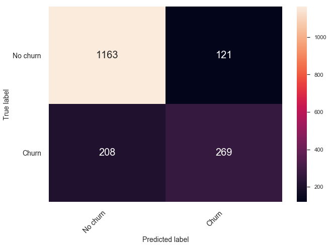

```python
from sklearn.linear_model import LogisticRegression
from sklearn.metrics import confusion_matrix, classification_report

logisticRegr = LogisticRegression()
logisticRegr.fit(X=train_x, y=train_y)

test_y_pred = logisticRegr.predict(test_x)
confusion_matrix = confusion_matrix(test_y, test_y_pred)
print('Intercept: ' + str(logisticRegr.intercept_))
print('Regression: ' + str(logisticRegr.coef_))
print('Accuracy of logistic regression classifier on test set: {:.2f}'.format(logisticRegr.score(test_x, test_y)))
print(classification_report(test_y, test_y_pred))

confusion_matrix_df = pd.DataFrame(confusion_matrix, ('No churn', 'Churn'), ('No churn', 'Churn'))
heatmap = sns.heatmap(confusion_matrix_df, annot=True, annot_kws={"size": 20}, fmt="d")
heatmap.yaxis.set_ticklabels(heatmap.yaxis.get_ticklabels(), rotation=0, ha='right', fontsize = 14)
heatmap.xaxis.set_ticklabels(heatmap.xaxis.get_ticklabels(), rotation=45, ha='right', fontsize = 14)
plt.ylabel('True label', fontsize = 14)
plt.xlabel('Predicted label', fontsize = 14)
```

#### Computing Accuracy

Classification accuracy from the logistic regression classifie is 81% however the precision and recall for predictions in the positive class (churn) are relatively low, which suggests our data set may be imbalanced.

```python
df['Churn'].value_counts()
```

```
0    5174
1    1869
Name: Churn, dtype: int64
```

```python
from sklearn.utils import resample

df_majority = df[df['Churn']==0]
df_minority = df[df['Churn']==1]

df_minority_upsampled = resample(df_minority,
replace=True,
n_samples=5174, #same number of samples as majority classe
random_state=1) #set the seed for random resampling
# Combine resampled results
df_upsampled = pd.concat([df_majority, df_minority_upsampled])

df_upsampled['Churn'].value_counts()
```

```
1    5174
0    5174
Name: Churn, dtype: int64
```

#### Rerun the model

```python
train, test = train_test_split(df_upsampled, test_size = 0.3)

train_y_upsampled = train['Churn']
test_y_upsampled = test['Churn']

train_x_upsampled = train
train_x_upsampled.pop('Churn')
test_x_upsampled = test
test_x_upsampled.pop('Churn')

logisticRegr_balanced = LogisticRegression()
logisticRegr_balanced.fit(X=train_x_upsampled, y=train_y_upsampled)

test_y_pred_balanced = logisticRegr_balanced.predict(test_x_upsampled)
print('Accuracy of logistic regression classifier on test set: {:.2f}'.format(logisticRegr_balanced.score(test_x_upsampled, test_y_upsampled)))
print(classification_report(test_y_upsampled, test_y_pred_balanced))
```

```
Accuracy of logistic regression classifier on test set: 0.76
              precision    recall  f1-score   support

           0       0.79      0.72      0.75      1615
           1       0.72      0.79      0.76      1490

   micro avg       0.76      0.76      0.76      3105
   macro avg       0.76      0.76      0.76      3105
weighted avg       0.76      0.76      0.76      3105
```

The overall accuracy of the model has decreased, but the precision and recall scores for predicting a churn have improved.